# Checkpoint1

Carlos Interaminense

July 25, 2017

```r
library(plotly)
library(ggplot2)
library(GGally)
library(dplyr)
library(tidyverse)
library(resample) # <-- Para bootstrap!
library(lubridate)
library(plyr)
theme_set(theme_bw())
```

# Dados de commits no GitHub

Usaremos neste relatório uma amostra dos dados do GitHub, que correspondem a quantidade de usuários que editaram arquivos com extensão em comum (arquivos referentes a linguagens de programação) em em um determindado dia. Sabemos que o GitHub dispõe de uma quantidade enorme de dados, chutaria algo como *Terabytes*, portanto, neste relatório vamos considerar apenas uma amostra desses dados referentes aos anos de 2016 e 2017 de arquivos com algumas extensões que são referentes as liguagens de programação (ex: java, js, py, entre outras).

## Descritivo dos dados

```r
#Carregando os dados
dados = read_csv("./github-users-commiting-filetypes.csv");
```

É esperado que:  
- os dias do mês estajam entre 1-31;  
- os meses estejam entre 1-12;  
- a quantidade de usuários não seja negativa ( < 0 )

A partir da tabela a seguir, podemos verificar que os dados estão dentro dos intervalos esperados.

```r
min_month_day = min(dados$month_day);
max_month_day = max(dados$month_day);
min_month = min(dados$the_month);
max_month = max(dados$the_month);
min_users = min(dados$users);
max_users = max(dados$users);


m  <- matrix(c(min_month_day, max_month_day, min_month, max_month, min_users, max_users), ncol=2,byrow = TRUE);
colnames(m) <- c("mínimo", "máximo")
rownames(m) <- c("Dias do mês", "Mês", "#Usuários")
m <- as.table(m)
m
```

```
##             mínimo máximo
## Dias do mês      1     31
## Mês              1     12
## #Usuários      501  10279
```

Em que, na Tabela acima, #Usuários é a quantidade de usuários.

Para termos uma noção da distribuição dos valores dos usuários, usaremos o boxplot abaixo:

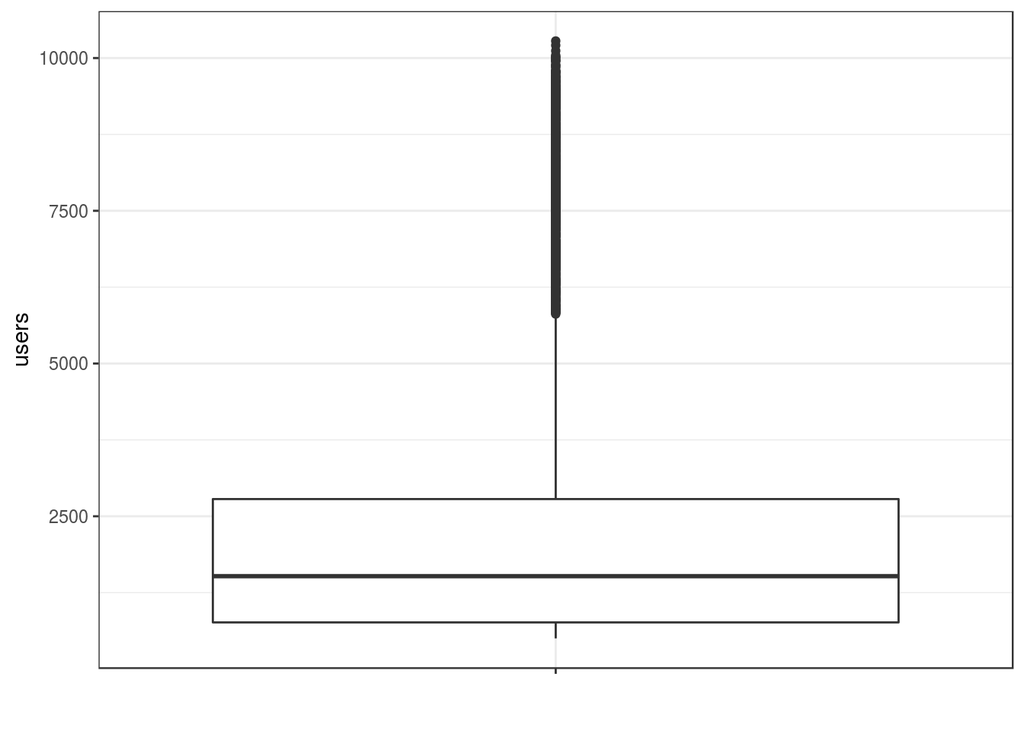

```r
dados %>%
  ggplot(aes(x = "", y = users)) +
  geom_boxplot() +
  xlab("")
```

O gráfico acima deixa claro que existem valores considerados *outliers* (sequência de pontos da cor preta na parte superior do boxplot). Uma forma de lidar com esses *outliers* é usar a mediana dos valores, já que a mesma não é influenciada por valores extremos. Logo, neste relatório, usaremos a mediana.

Agora podemos prosseguir com o relatório…

# Pergunta 1: No geral (independente da linguagem de programação), as pessoas programam mais durante a semana ou no final de semana? Essa diferença é grande?

Para responder esta pergunta, temos que saber se os usuários modificaram os arquivos durante a semana ou no final de semana e, como queremos saber o resultado independente da linguagem de programação, temos que agrupar os dados pela a data, somando as modificações daquele dia para qualquer linguagem de programação.

Agora, podemos verificar se as pessoas programam mais durante a semana ou durante os finais de semana, usando a técnica de bootstrap..

```r
dados$date <- paste(dados$month_day, dados$the_month, dados$the_year, sep = "-")

dados.agrupados <- aggregate(dados[, 5], list(dados$date), sum)

dados.agrupados  <- dados.agrupados %>%
  mutate(nome_dia = weekdays(as.Date(Group.1,'%d-%m-%Y')) )

dados.agrupados  <- dados.agrupados %>%
    mutate(is_fds = (nome_dia == 'sábado' | nome_dia== 'domingo' )   )

dados.agrupados  <- dados.agrupados %>%
  mutate(mes = month(as.Date(Group.1,'%d-%m-%Y')) )

# Galera do FDS
b1 = dados.agrupados %>%
  filter(is_fds) %>%
  bootstrap(median(users))

median.fds = b1 %>%
  CI.percentile(props = c(.025, .975))

# Galera da semana (seg-sexta)
b2 = dados.agrupados %>%
  filter(is_fds != TRUE) %>%
  bootstrap(median(users))

median.semana = b2 %>%
  CI.percentile(props = c(.025, .975))

df.medians = data.frame(rbind(median.fds, median.semana))
```

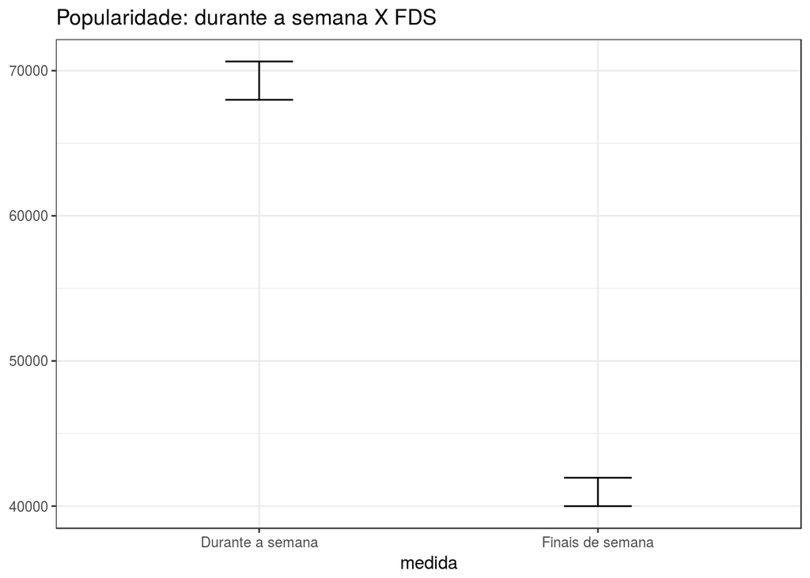

```r
df.medians$medida= c("Finais de semana", "Durante a semana")

df.medians %>%
  ggplot(aes(x = medida, ymin = X2.5., ymax = X97.5.)) +
  geom_errorbar(width = .2) +
  ggtitle("Popularidade: durante a semana X FDS")
```

A partir do gráfico acima percebemos que as pessoas preferem programar durante a semana do que no final de semana e podemos perceber também que a diferença é grande. O gráfico a seguir nos ajuda a entender ainda mais a nossa conclusão.

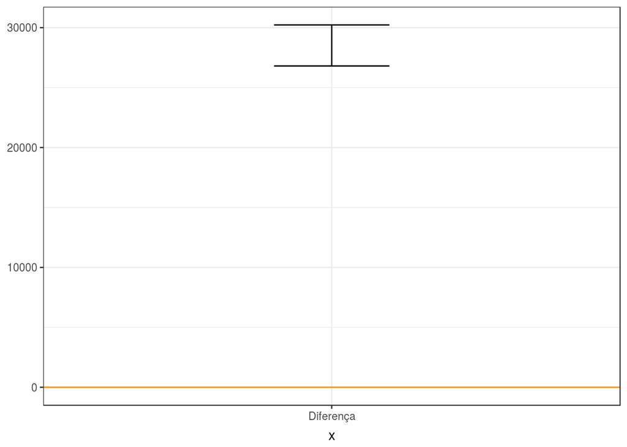

```r
fds <- dados.agrupados %>%
  filter(is_fds)
semana <- dados.agrupados %>%
  filter(is_fds == FALSE)

b <- bootstrap2( data = semana$users,
                 data2 = fds$users,
                 median)

b.ci = CI.percentile(b, probs = c(.025, .975))

data.frame(b.ci) %>%
  ggplot(aes(x = "Diferença", ymin = X2.5., ymax = X97.5.)) +
  geom_errorbar(width = .2) +
  geom_hline(yintercept = 0, colour = "darkorange")
```

Percebam que o valor 0 (zero) não está entre o intervalo de confiança, o que nos faz concluir que é significativa a preferência de programar durante a semana do que no final de semana.

# Pergunta 1.1 - Sabendo qual o período da semana (fds ou nao) que as pessoas mais programam (Pergunta 1), qual o dia desse período que as pessoas mais programam? A diferença é grande, com relação aos outros dias?

Para responder esta pergunta, devemos usaremos a mesma lógica da questão anterior (agrupando os dados pela data, omando as modificações daquele dia para qualquer linguagem de programação), mas agora queremos saber qual o dia que as pessoas mais programam. Para fazer isso, vamos visualizar os dados referentes a cada dia, também usando a técnica bootstrap:

```r
# segunda
median.segunda = dados.agrupados %>%
  filter(nome_dia == "segunda") %>%
  bootstrap(median(users)) %>%
  CI.percentile(props = c(.025, .975))

# terça
median.terça = dados.agrupados %>%
  filter(nome_dia == "terça") %>%
  bootstrap(median(users)) %>%
  CI.percentile(props = c(.025, .975))

# quarta
median.quarta = dados.agrupados %>%
  filter(nome_dia == "quarta") %>%
  bootstrap(median(users))%>%
  CI.percentile(props = c(.025, .975))

# quinta
median.quinta  = dados.agrupados %>%
  filter(nome_dia == "quinta") %>%
  bootstrap(median(users)) %>%
  CI.percentile(props = c(.025, .975))

# sexta
median.sexta = dados.agrupados %>%
  filter(nome_dia == "sexta") %>%
  bootstrap(median(users)) %>%
  CI.percentile(props = c(.025, .975))

df.medians = data.frame(rbind(median.segunda, median.terça, median.quarta, median.quinta, median.sexta))
```

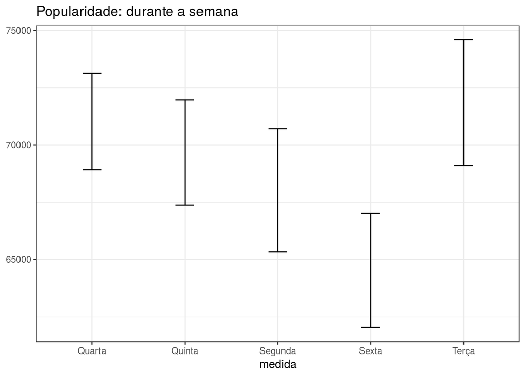

```r
df.medians$medida= c("Segunda", "Terça", "Quarta", "Quinta", "Sexta")

df.medians %>%
  ggplot(aes(x = medida, ymin = X2.5., ymax = X97.5.)) +
  geom_errorbar(width = .2) +
  ggtitle("Popularidade: durante a semana")
```

As conclusões que podemos tomar com base no gráfico acima é que as pessoas programam mais nas terças, quartas e quintas do que nas sextas. Não podemos concluir qual o dia da semana que as pessoas mais programam, pois existe um “empate técnico” entre: segunda, terça, quarta e quinta. Esse “empate técnico” existe porque existe interseção entre os intervalos da segunda, terça, quarta e quinta.

# Pergunta 2: Considerando as linguagens de programação: Python e JavaScript, qual delas é a mais popular no período de férias (janeiro,Junho e dezembro)?

Para responder esta pergunta, temos que agrupar as duas linguagens de programação. Na resposta desta pergunta, também usaremos a técnica booststrap, dessa vez considerando apenas os meses de férias.

O gráfico a seguir mostra os resultados obtidos.

```r
dados_python = dados %>%
  filter(file_extension == "py")

dados_javascript = dados %>%
  filter(file_extension == "js")

# férias python
median_python.férias = dados_python %>%
  filter(the_month == 1 | the_month == 6 | the_month == 12) %>%
  bootstrap(median(users)) %>%
  CI.percentile(props = c(.025, .975))

# férias JavaScript
median_javascript.férias = dados_javascript %>%
  filter(the_month == 1 | the_month == 6 | the_month == 12) %>%
  bootstrap(median(users)) %>%
  CI.percentile(props = c(.025, .975))

df.medians = data.frame(rbind(median_python.férias, median_javascript.férias))
```

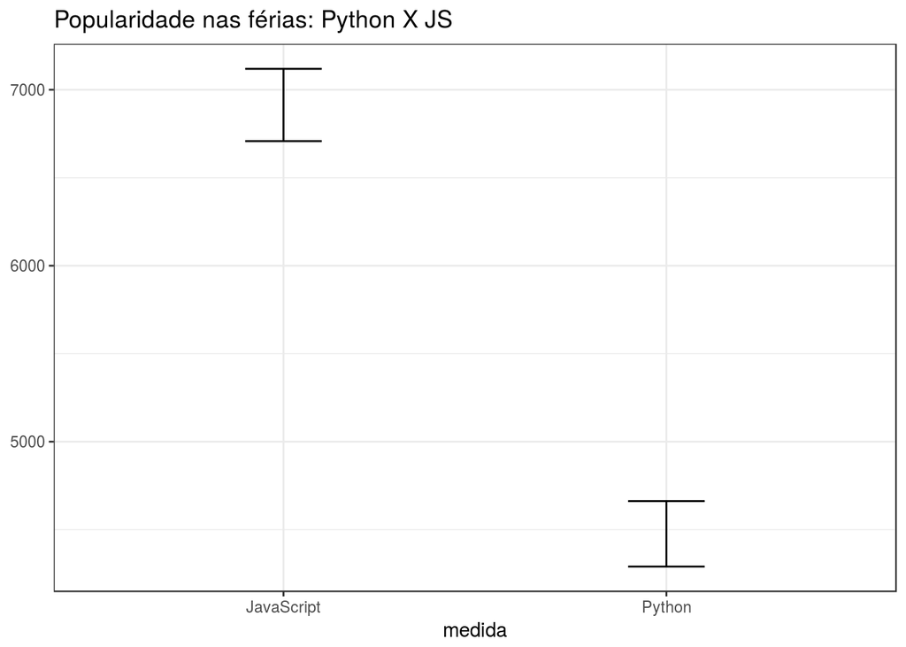

```r
df.medians$medida= c("Python", "JavaScript")

df.medians %>%
  ggplot(aes(x = medida, ymin = X2.5., ymax = X97.5.)) +
  geom_errorbar(width = .2) +
  ggtitle("Popularidade nas férias: Python X JS")
```

A partir do gráfico acima, percebemos que as pessoas preferem programar em JavaScript do que em Python, no período de férias. Percebemos também que esta diferença é grande.

# Pergunta 2.1: Considerando a linguagem de programação JavaScript como sendo as que as pessoas mais programam nas férias (resposta da questão 2), elas programam mais durante a semana ou nos finais de semana neste período de férias, ou seja, a resposta da questão 1 se mantém?

Esta resposta é similiar a resposta da questão 1, mas usaremos apenas os dados referentes a JavaScript. A seguir é mostrado o gráfico com os resultados obtidos.

```r
dados_javascript  <- dados_javascript %>%
  mutate(nome_dia = weekdays(as.Date(date,'%d-%m-%Y')) )

dados_javascript  <- dados_javascript %>%
    mutate(is_fds = (nome_dia == 'sábado' | nome_dia== 'domingo' )   )

# Galera do FDS
median.fds = dados_javascript %>%
  filter(the_month == 1 | the_month == 6 | the_month == 12) %>%
  filter(is_fds) %>%
  bootstrap(median(users))%>%
  CI.percentile(props = c(.025, .975))

# Galera da semana (seg-sexta)
median.semana = dados_javascript %>%
  filter(the_month == 1 | the_month == 6 | the_month == 12) %>%
  filter(is_fds != TRUE) %>%
  bootstrap(median(users)) %>%
  CI.percentile(props = c(.025, .975))

df.medians = data.frame(rbind(median.fds, median.semana))
```

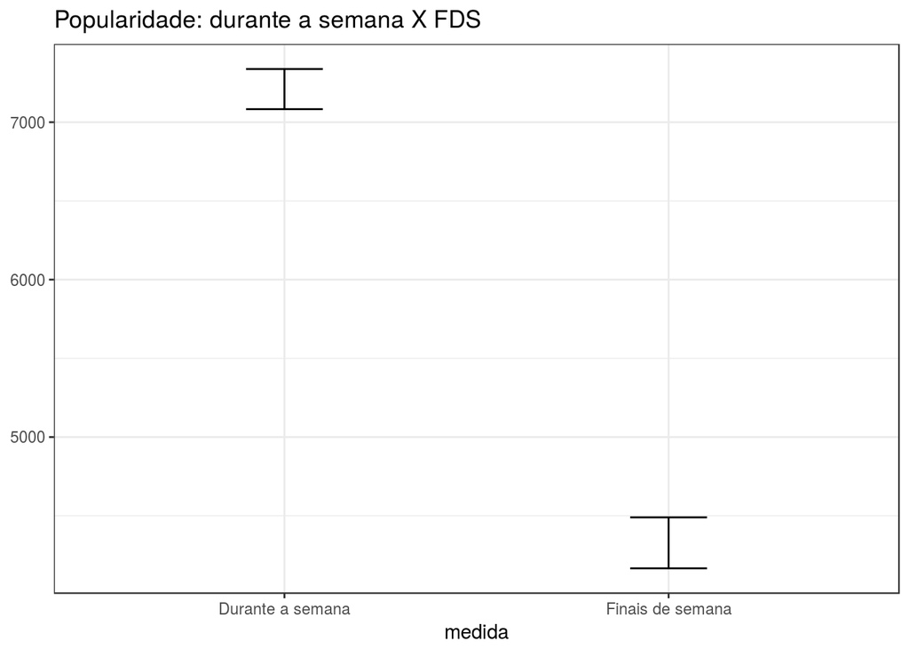

```r
df.medians$medida= c("Finais de semana", "Durante a semana")

df.medians %>%
  ggplot(aes(x = medida, ymin = X2.5., ymax = X97.5.)) +
  geom_errorbar(width = .2) +
  ggtitle("Popularidade: durante a semana X FDS")
```

Percebemos que as pessas ainda preferem programar durante a semana em javaScript, mesmo estando de férias. Percebe-se também, que esta diferença é grande. Logo, a resposra da questão 1 se mantém verdadeira com a linguagem JavaScript durante as férias.

O gráfico a seguir nos ajuda a entender ainda mais a nossa conclusão.

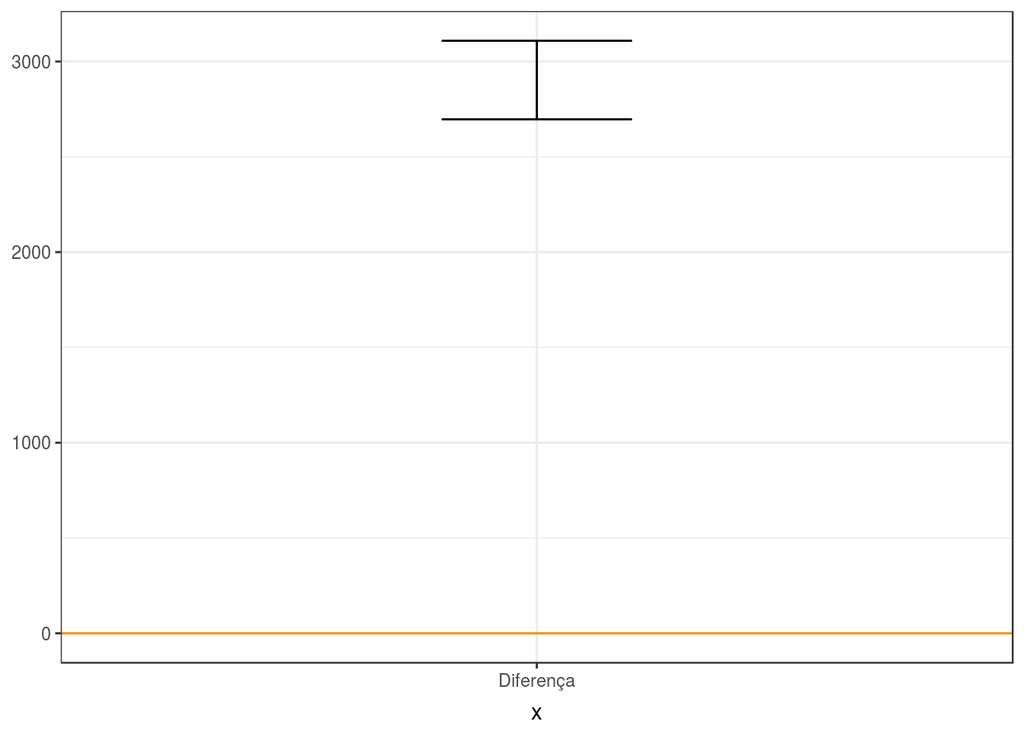

```r
fds <- dados_javascript %>%
  filter(the_month == 1 | the_month == 6 | the_month == 12) %>%
  filter(is_fds)

semana <- dados_javascript %>%
  filter(the_month == 1 | the_month == 6 | the_month == 12) %>%
  filter(is_fds == FALSE)

b <- bootstrap2( data = semana$users,
                 data2 = fds$users,
                 median)

b.ci = CI.percentile(b, probs = c(.025, .975))

data.frame(b.ci) %>%
  ggplot(aes(x = "Diferença", ymin = X2.5., ymax = X97.5.)) +
  geom_errorbar(width = .2) +
  geom_hline(yintercept = 0, colour = "darkorange")
```

Percebam que o valor 0 (zero) não está entre o intervalo de confiança, o que nos faz concluir que é significativa a preferência de programar em JavaScript nas férias, durante a semana do que no final de semana.